# LAB6

2/19/2019

## Outline

**Dataset available on the web (awesome):**

- https://github.com/briatte/awesome-network-analysis Papers, reviews, dataset, software (tutorial)
- Katherine’s webpage http://kateto.net/2016/05/network-datasets/
- Kaggle https://www.kaggle.com/datasets
- dataworld https://data.world/search?q=network+dataset

**Web scraping:**

- Web APIs(application programming interface): website offers a set of structured http requests that return JSON or XML files. `rtweet`,`twitteR`,`Rfacebook`
- Screen scraping: extract data from source code of website, with html parser or regular expression matching. (lab 7)

**Twitter API**

## R package `rtweet`

Official website: https://rtweet.info/index.html

**Explore the official websites to find more info.**

- All the functions
- Tutorial
- FAQ (possible issues)

Good documentation; Recommended over another R package `twitteR`.

## Preparation

```r
#install.packages("rtweet")
library("rtweet")
```

## API authorization

Follow https://rtweet.info/articles/auth.html

- Create a Twitter App
- Authorization via access token: `create_token()` automatically saves your token as an environment variable, you’ll be set for future sessions as well!

```r
#save your token as an environment variable for you
create_token(
  app = "your_research_app",
  consumer_key = "consumer_API_key",
  consumer_secret = "consumer_API_secret_key",
  access_token = "access_token",
  access_secret = "access_token_secret")
```

## `rtweet`

**API request**

- https://developer.twitter.com/en/docs/tweets/search/api-reference/get-search-tweets
- Send a request specifying parameters; Get response in JSON format
- `search_tweets`: **sampling** from tweets in past 7 days matching keywords (**specified # of tweets**) – recent/popular/mixed
- `stream_tweets`: sampling/keyword-filter/user-track/geo-location **live stream** for future time period;(**specified time period**)

## `search_tweets`

- limiting searches to 10 keywords and operators
- only past 6-9 days of Tweets

**Parameters:**

`help()` or see https://developer.twitter.com/en/docs/tweets/search/api-reference/get-search-tweets

- `q`: Query to be searched. Spaces/AND – both (“data science”;“data AND science”); OR – either or (data OR science); ’"“’ – exact (‘“data science”’;”"data science"“);”#datascience" – track hashtag; “@duke” – track at.

See operators: https://developer.twitter.com/en/docs/tweets/rules-and-filtering/overview/standard-operators.html

- `n`: total number of desired tweets. At most 18,000 in a single call; For \(>\) 18,000, `retryonratelimit`=TRUE
- `type`: “recent”,“popular”,“mixed”
- `include_rts`: whether to include retweets
- `geocode`: “latitude,longitude,radius”
- `lang`: language
- `parse`: TRUE(dateframe); FALSE(list)

```r
rt <- search_tweets(
  q="#dukebasketball", #Query to be searched
  n = 10,
include_rts=FALSE,
result_type="recent",
geocode = "36.00,-78.94,5mi"
)
```

```
## Searching for tweets...
```

```
## Finished collecting tweets!
```

```r
rt
```

```
## # A tibble: 10 x 88
##    user_id status_id created_at          screen_name text  source
##    <chr>   <chr>     <dttm>              <chr>       <chr> <chr>
##  1 108943… 10977000… 2019-02-19 03:30:59 TheBlueDev… JJ w… Twitt…
##  2 108943… 10975646… 2019-02-18 18:32:59 TheBlueDev… In o… Twitt…
##  3 108943… 10975642… 2019-02-18 18:31:32 TheBlueDev… "Lot… Twitt…
##  4 108943… 10957592… 2019-02-13 18:58:56 TheBlueDev… This… Twitt…
##  5 108943… 10969352… 2019-02-17 00:51:57 TheBlueDev… Ever… Twitt…
##  6 193467… 10975501… 2019-02-18 17:35:20 DukeGardens Red+… Twitt…
##  7 119143… 10974703… 2019-02-18 12:18:20 Sir_dEButa… "😈 🏀… Insta…
##  8 239153… 10969394… 2019-02-17 01:08:43 cdkassotis  Brin… Twitt…
##  9 819357… 10967814… 2019-02-16 14:40:43 DukeDigest  "🔵 G… Twitt…
## 10 791668… 10957408… 2019-02-13 17:45:49 DiscoverDu… Happ… Hoots…
## # … with 82 more variables: display_text_width <dbl>,
## #   reply_to_status_id <lgl>, reply_to_user_id <lgl>,
## #   reply_to_screen_name <lgl>, is_quote <lgl>, is_retweet <lgl>,
## #   favorite_count <int>, retweet_count <int>, hashtags <list>,
## #   symbols <list>, urls_url <list>, urls_t.co <list>,
## #   urls_expanded_url <list>, media_url <list>, media_t.co <list>,
## #   media_expanded_url <list>, media_type <list>, ext_media_url <list>,
## #   ext_media_t.co <list>, ext_media_expanded_url <list>,
## #   ext_media_type <chr>, mentions_user_id <list>,
## #   mentions_screen_name <list>, lang <chr>, quoted_status_id <chr>,
## #   quoted_text <chr>, quoted_created_at <dttm>, quoted_source <chr>,
## #   quoted_favorite_count <int>, quoted_retweet_count <int>,
## #   quoted_user_id <chr>, quoted_screen_name <chr>, quoted_name <chr>,
## #   quoted_followers_count <int>, quoted_friends_count <int>,
## #   quoted_statuses_count <int>, quoted_location <chr>,
## #   quoted_description <chr>, quoted_verified <lgl>,
## #   retweet_status_id <chr>, retweet_text <chr>,
## #   retweet_created_at <dttm>, retweet_source <chr>,
## #   retweet_favorite_count <int>, retweet_retweet_count <int>,
## #   retweet_user_id <chr>, retweet_screen_name <chr>, retweet_name <chr>,
## #   retweet_followers_count <int>, retweet_friends_count <int>,
## #   retweet_statuses_count <int>, retweet_location <chr>,
## #   retweet_description <chr>, retweet_verified <lgl>, place_url <chr>,
## #   place_name <chr>, place_full_name <chr>, place_type <chr>,
## #   country <chr>, country_code <chr>, geo_coords <list>,
## #   coords_coords <list>, bbox_coords <list>, status_url <chr>,
## #   name <chr>, location <chr>, description <chr>, url <chr>,
## #   protected <lgl>, followers_count <int>, friends_count <int>,
## #   listed_count <int>, statuses_count <int>, favourites_count <int>,
## #   account_created_at <dttm>, verified <lgl>, profile_url <chr>,
## #   profile_expanded_url <chr>, account_lang <chr>,
## #   profile_banner_url <chr>, profile_background_url <chr>,
## #   profile_image_url <chr>
```

```r
rt <- search_tweets(
  "trump OR president", n = 10,
  lang = "en"
)
```

```
## Searching for tweets...
## Finished collecting tweets!
```

```r
rt
```

```
## # A tibble: 9 x 88
##   user_id status_id created_at          screen_name text  source
##   <chr>   <chr>     <dttm>              <chr>       <chr> <chr>
## 1 887569… 10979173… 2019-02-19 17:54:33 covefefe_j… "Dem… Twitt…
## 2 161257… 10979173… 2019-02-19 17:54:33 parkse      "It’… Twitt…
## 3 874801… 10979173… 2019-02-19 17:54:33 juliahomew… "@re… Twitt…
## 4 928885… 10979173… 2019-02-19 17:54:33 enufs_enuf  @rea… Twitt…
## 5 236415… 10979173… 2019-02-19 17:54:33 BOBSarmymom The … Twitt…
## 6 262948… 10979173… 2019-02-19 17:54:33 higginsgggg "\"P… Twitt…
## 7 609398… 10979173… 2019-02-19 17:54:33 Greg05Jack… Pres… Twitt…
## 8 271978… 10979173… 2019-02-19 17:54:33 Coalminetw… "@Ch… Twitt…
## 9 826914… 10979173… 2019-02-19 17:54:33 blackopscy… Hous… dlvr.…
## # … with 82 more variables: display_text_width <dbl>,
## #   reply_to_status_id <chr>, reply_to_user_id <chr>,
## #   reply_to_screen_name <chr>, is_quote <lgl>, is_retweet <lgl>,
## #   favorite_count <int>, retweet_count <int>, hashtags <list>,
## #   symbols <list>, urls_url <list>, urls_t.co <list>,
## #   urls_expanded_url <list>, media_url <list>, media_t.co <list>,
## #   media_expanded_url <list>, media_type <list>, ext_media_url <list>,
## #   ext_media_t.co <list>, ext_media_expanded_url <list>,
## #   ext_media_type <chr>, mentions_user_id <list>,
## #   mentions_screen_name <list>, lang <chr>, quoted_status_id <chr>,
## #   quoted_text <chr>, quoted_created_at <dttm>, quoted_source <chr>,
## #   quoted_favorite_count <int>, quoted_retweet_count <int>,
## #   quoted_user_id <chr>, quoted_screen_name <chr>, quoted_name <chr>,
## #   quoted_followers_count <int>, quoted_friends_count <int>,
## #   quoted_statuses_count <int>, quoted_location <chr>,
## #   quoted_description <chr>, quoted_verified <lgl>,
## #   retweet_status_id <chr>, retweet_text <chr>,
## #   retweet_created_at <dttm>, retweet_source <chr>,
## #   retweet_favorite_count <int>, retweet_retweet_count <int>,
## #   retweet_user_id <chr>, retweet_screen_name <chr>, retweet_name <chr>,
## #   retweet_followers_count <int>, retweet_friends_count <int>,
## #   retweet_statuses_count <int>, retweet_location <chr>,
## #   retweet_description <chr>, retweet_verified <lgl>, place_url <chr>,
## #   place_name <chr>, place_full_name <chr>, place_type <chr>,
## #   country <chr>, country_code <chr>, geo_coords <list>,
## #   coords_coords <list>, bbox_coords <list>, status_url <chr>,
## #   name <chr>, location <chr>, description <chr>, url <chr>,
## #   protected <lgl>, followers_count <int>, friends_count <int>,
## #   listed_count <int>, statuses_count <int>, favourites_count <int>,
## #   account_created_at <dttm>, verified <lgl>, profile_url <chr>,
## #   profile_expanded_url <chr>, account_lang <chr>,
## #   profile_banner_url <chr>, profile_background_url <chr>,
## #   profile_image_url <chr>
```

```r
search_tweets(
  q="#dukebasketball", #Query to be searched
  n = 10,
include_rts=FALSE,
result_type="recent",
geocode = "36.00,-78.94,5mi"
)
```

```
## Searching for tweets...
## Finished collecting tweets!
```

```
## # A tibble: 10 x 88
##    user_id status_id created_at          screen_name text  source
##    <chr>   <chr>     <dttm>              <chr>       <chr> <chr>
##  1 108943… 10977000… 2019-02-19 03:30:59 TheBlueDev… JJ w… Twitt…
##  2 108943… 10975646… 2019-02-18 18:32:59 TheBlueDev… In o… Twitt…
##  3 108943… 10975642… 2019-02-18 18:31:32 TheBlueDev… "Lot… Twitt…
##  4 108943… 10957592… 2019-02-13 18:58:56 TheBlueDev… This… Twitt…
##  5 108943… 10969352… 2019-02-17 00:51:57 TheBlueDev… Ever… Twitt…
##  6 193467… 10975501… 2019-02-18 17:35:20 DukeGardens Red+… Twitt…
##  7 119143… 10974703… 2019-02-18 12:18:20 Sir_dEButa… "😈 🏀… Insta…
##  8 239153… 10969394… 2019-02-17 01:08:43 cdkassotis  Brin… Twitt…
##  9 819357… 10967814… 2019-02-16 14:40:43 DukeDigest  "🔵 G… Twitt…
## 10 791668… 10957408… 2019-02-13 17:45:49 DiscoverDu… Happ… Hoots…
## # … with 82 more variables: display_text_width <dbl>,
## #   reply_to_status_id <lgl>, reply_to_user_id <lgl>,
## #   reply_to_screen_name <lgl>, is_quote <lgl>, is_retweet <lgl>,
## #   favorite_count <int>, retweet_count <int>, hashtags <list>,
## #   symbols <list>, urls_url <list>, urls_t.co <list>,
## #   urls_expanded_url <list>, media_url <list>, media_t.co <list>,
## #   media_expanded_url <list>, media_type <list>, ext_media_url <list>,
## #   ext_media_t.co <list>, ext_media_expanded_url <list>,
## #   ext_media_type <chr>, mentions_user_id <list>,
## #   mentions_screen_name <list>, lang <chr>, quoted_status_id <chr>,
## #   quoted_text <chr>, quoted_created_at <dttm>, quoted_source <chr>,
## #   quoted_favorite_count <int>, quoted_retweet_count <int>,
## #   quoted_user_id <chr>, quoted_screen_name <chr>, quoted_name <chr>,
## #   quoted_followers_count <int>, quoted_friends_count <int>,
## #   quoted_statuses_count <int>, quoted_location <chr>,
## #   quoted_description <chr>, quoted_verified <lgl>,
## #   retweet_status_id <chr>, retweet_text <chr>,
## #   retweet_created_at <dttm>, retweet_source <chr>,
## #   retweet_favorite_count <int>, retweet_retweet_count <int>,
## #   retweet_user_id <chr>, retweet_screen_name <chr>, retweet_name <chr>,
## #   retweet_followers_count <int>, retweet_friends_count <int>,
## #   retweet_statuses_count <int>, retweet_location <chr>,
## #   retweet_description <chr>, retweet_verified <lgl>, place_url <chr>,
## #   place_name <chr>, place_full_name <chr>, place_type <chr>,
## #   country <chr>, country_code <chr>, geo_coords <list>,
## #   coords_coords <list>, bbox_coords <list>, status_url <chr>,
## #   name <chr>, location <chr>, description <chr>, url <chr>,
## #   protected <lgl>, followers_count <int>, friends_count <int>,
## #   listed_count <int>, statuses_count <int>, favourites_count <int>,
## #   account_created_at <dttm>, verified <lgl>, profile_url <chr>,
## #   profile_expanded_url <chr>, account_lang <chr>,
## #   profile_banner_url <chr>, profile_background_url <chr>,
## #   profile_image_url <chr>
```

## `search_tweets`

- dataframe: each row a tweet
- `users_data`: only extract user-related column
- `ts_plot`
- `lat_lng`

```r
## search for 18000 tweets using the rstats hashtag
rt <- search_tweets(
  "#dukebasketball", n = 50000, include_rts = FALSE,
  geocode = "36.00,-78.94,2000mi"
)
```

```
## Searching for tweets...
```

```
## This may take a few seconds...
```

```
## Finished collecting tweets!
```

```r
rt_dmbb=rt
class(rt)
```

```
## [1] "tbl_df"     "tbl"        "data.frame"
```

```r
## preview tweets data
names(rt)
```

```
##  [1] "user_id"                 "status_id"
##  [3] "created_at"              "screen_name"
##  [5] "text"                    "source"
##  [7] "display_text_width"      "reply_to_status_id"
##  [9] "reply_to_user_id"        "reply_to_screen_name"
## [11] "is_quote"                "is_retweet"
## [13] "favorite_count"          "retweet_count"
## [15] "hashtags"                "symbols"
## [17] "urls_url"                "urls_t.co"
## [19] "urls_expanded_url"       "media_url"
## [21] "media_t.co"              "media_expanded_url"
## [23] "media_type"              "ext_media_url"
## [25] "ext_media_t.co"          "ext_media_expanded_url"
## [27] "ext_media_type"          "mentions_user_id"
## [29] "mentions_screen_name"    "lang"
```

[output cut: 29 more lines]

```r
## preview users data
users_data(rt)%>%names()
```

```
##  [1] "user_id"                "screen_name"
##  [3] "name"                   "location"
##  [5] "description"            "url"
##  [7] "protected"              "followers_count"
##  [9] "friends_count"          "listed_count"
## [11] "statuses_count"         "favourites_count"
## [13] "account_created_at"     "verified"
## [15] "profile_url"            "profile_expanded_url"
## [17] "account_lang"           "profile_banner_url"
## [19] "profile_background_url" "profile_image_url"
```

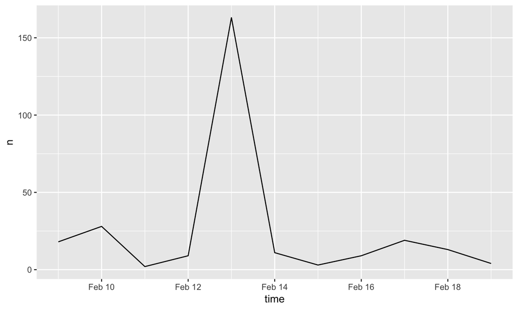

```r
## plot time series (if ggplot2 is installed)
ts_plot(rt) #Duke vs No. 16 Louisville
```

## `search_tweets2`

Search different queries independently.

Other parameters are the same.

```r
st2 <- search_tweets2(
  c("\"data science\"", "rstats OR python"),
  n = 50
)
```

```
## Searching for tweets...
```

```
## Finished collecting tweets!
```

```
## Searching for tweets...
```

```
## Finished collecting tweets!
```

```r
st2$query
```

```
##   [1] "\"data science\"" "\"data science\"" "\"data science\""
##   [4] "\"data science\"" "\"data science\"" "\"data science\""
##   [7] "\"data science\"" "\"data science\"" "\"data science\""
##  [10] "\"data science\"" "\"data science\"" "\"data science\""
##  [13] "\"data science\"" "\"data science\"" "\"data science\""
##  [16] "\"data science\"" "\"data science\"" "\"data science\""
##  [19] "\"data science\"" "\"data science\"" "\"data science\""
##  [22] "\"data science\"" "\"data science\"" "\"data science\""
##  [25] "\"data science\"" "\"data science\"" "\"data science\""
##  [28] "\"data science\"" "\"data science\"" "\"data science\""
##  [31] "\"data science\"" "\"data science\"" "\"data science\""
##  [34] "\"data science\"" "\"data science\"" "\"data science\""
##  [37] "\"data science\"" "\"data science\"" "\"data science\""
##  [40] "\"data science\"" "\"data science\"" "\"data science\""
##  [43] "\"data science\"" "\"data science\"" "\"data science\""
```

[output cut: 19 more lines]

```r
names(st2)
```

```
##  [1] "user_id"                 "status_id"
##  [3] "created_at"              "screen_name"
##  [5] "text"                    "source"
##  [7] "display_text_width"      "reply_to_status_id"
##  [9] "reply_to_user_id"        "reply_to_screen_name"
## [11] "is_quote"                "is_retweet"
## [13] "favorite_count"          "retweet_count"
## [15] "hashtags"                "symbols"
## [17] "urls_url"                "urls_t.co"
## [19] "urls_expanded_url"       "media_url"
## [21] "media_t.co"              "media_expanded_url"
## [23] "media_type"              "ext_media_url"
## [25] "ext_media_t.co"          "ext_media_expanded_url"
## [27] "ext_media_type"          "mentions_user_id"
## [29] "mentions_screen_name"    "lang"
```

[output cut: 30 more lines]

## Visualization

`research_tweets` returns a dataframe. Visualization based on the dataframe.

- `ts_plot`: Creates a ggplot2 plot of the frequency of tweets over a specified interval of time. Using `ggplot2`;
- Map: Using `lat_lng`

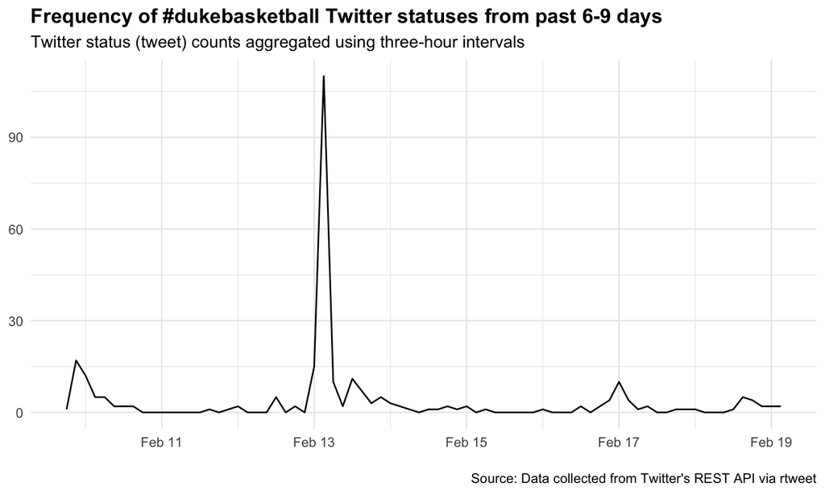

```r
## plot time series of tweets
ts_plot(rt_dmbb, "3 hours") + # a ggplot object
  ggplot2::theme_minimal() + # Add multiple layers directly
  ggplot2::theme(plot.title = ggplot2::element_text(face = "bold")) +
  ggplot2::labs(
    x = NULL, y = NULL,
    title = "Frequency of #dukebasketball Twitter statuses from past 6-9 days",
    subtitle = "Twitter status (tweet) counts aggregated using three-hour intervals",
    caption = "\nSource: Data collected from Twitter's REST API via rtweet"
  )
```

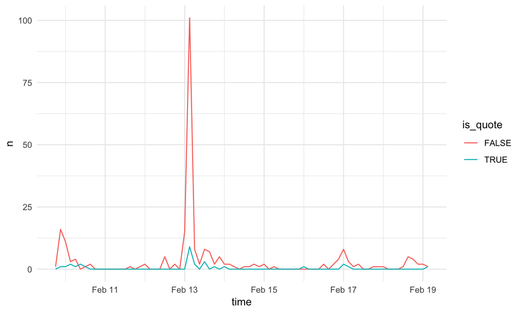

```r
# an example using `groupby` with ggplot2
ts_plot(rt_dmbb%>%dplyr::group_by(is_quote), "3 hours") + # a ggplot object
  ggplot2::theme_minimal()
```

```r
#install.packages("maps")
## create lat/lng variables using all available tweet and profile geo-location data
rt_dmbbll <- lat_lng(rt_dmbb)
names(rt_dmbbll)[!names(rt_dmbbll)%in%names(rt_dmbb)]
```

```
## [1] "lat" "lng"
```

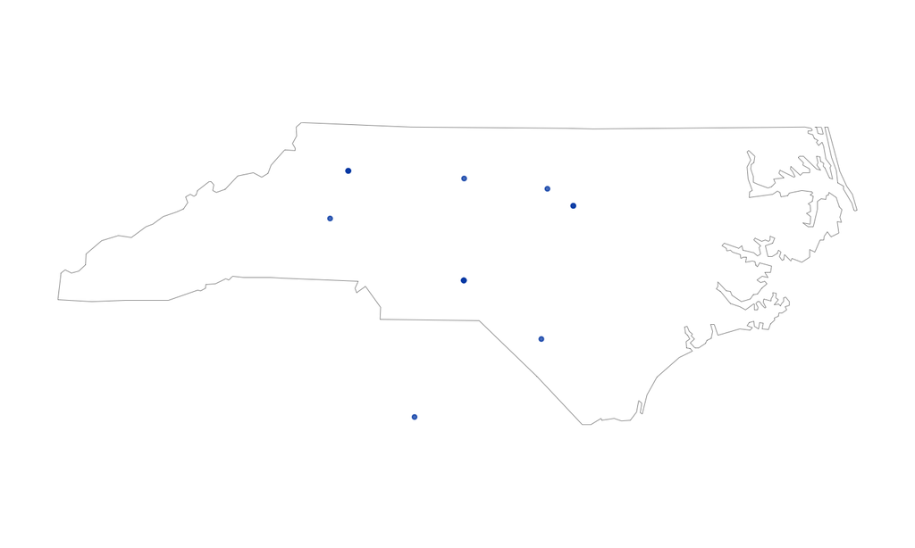

```r
## plot state boundaries
par(mar = c(0, 0, 0, 0))
maps::map("state","north carolina", lwd = .25)

## plot lat and lng points onto state map
with(rt_dmbbll, points(lng, lat, pch = 20, cex = .75, col = rgb(0, .3, .7, .75)))
```

## `stream_tweets`

https://developer.twitter.com/en/docs/tweets/search/api-reference/get-search-tweets

- `q`
  - Sampling a small random sample of all publicly available tweets `q=""`
  - Filtering via a search-like query (up to 400 keywords) `q="duke,basketball"`. “,” separation
  - Tracking via vector of user ids (up to 5000 user_ids) `q="hillaryclinton,realdonaldtrump"`. “,” separation
  - Location via geo coordinates (1-360 degree location boxes) `q=c(-125, 26, -65, 49)`
- `timeout` : amount of time (seconds) **occupy your r session**
- `parse`: TRUE(dataframe); FALSE(JSON).
- `file_name`: save as a file

**Usually the file is large. Recommend to save as JSON file then parse to data.frame.**

To ensure the stream automatically reconnects following any interruption prior to the specified stream time, use `stream_tweets2()`.

```r
## Randomly sample (approximately 1%) from the live stream of all tweets for 30 seconds (default)
rt <- stream_tweets("")
```

```
## Streaming tweets for 30 seconds...
```

```
## Finished streaming tweets!
```

```
## opening file input connection.
```

```
##
 Found 500 records...
 Found 1000 records...
 Found 1303 records...
 Imported 1303 records. Simplifying...
```

```
## closing file input connection.
```

```r
nrow(rt)
```

[output not shown]

```r
rt <- stream_tweets("duke,bluedevil,unc")
```

```
## Streaming tweets for 30 seconds...
```

```
## Finished streaming tweets!
```

```
## opening file input connection.
```

```
##
 Found 14 records...
 Imported 14 records. Simplifying...
```

```
## closing file input connection.
```

```r
nrow(rt)
```

```
## [1] 14
```

```r
rt
```

```
## # A tibble: 14 x 88
##    user_id status_id created_at          screen_name text  source
##    <chr>   <chr>     <dttm>              <chr>       <chr> <chr>
##  1 266759… 10979160… 2019-02-19 17:49:10 _BigSheed   And … Twitt…
##  2 125607… 10979160… 2019-02-19 17:49:13 PoopersJJo… .. @… Twitt…
##  3 140196… 10979160… 2019-02-19 17:49:13 Kgomez83    "The… Twitt…
##  4 343216… 10979160… 2019-02-19 17:49:13 BigTeddyWi… He t… Twitt…
##  5 413327… 10979160… 2019-02-19 17:49:16 ScottFordT… I re… Twitt…
##  6 241654… 10979160… 2019-02-19 17:49:17 UNCRecruits UNC … Twitt…
##  7 356610… 10979160… 2019-02-19 17:49:18 DLReich     Duke… Twitt…
##  8 376666… 10979160… 2019-02-19 17:49:19 alexispiru… "Zio… Twitt…
##  9 102439… 10979160… 2019-02-19 17:49:22 HalogenThe  "Joh… Twitt…
## 10 706638… 10979160… 2019-02-19 17:49:29 GDTBATH2017 #Tar… Twitt…
## 11 706638… 10979161… 2019-02-19 17:49:36 GDTBATH2017 #Tar… Twitt…
## 12 254904… 10979161… 2019-02-19 17:49:31 marcus_cur… @Tyl… Twitt…
## 13 284667… 10979161… 2019-02-19 17:49:38 SwerveKnows Stil… Twitt…
## 14 250281… 10979161… 2019-02-19 17:49:39 willballer8 Duke… Twitt…
## # … with 82 more variables: display_text_width <dbl>,
## #   reply_to_status_id <chr>, reply_to_user_id <chr>,
## #   reply_to_screen_name <chr>, is_quote <lgl>, is_retweet <lgl>,
## #   favorite_count <int>, retweet_count <int>, hashtags <list>,
## #   symbols <list>, urls_url <list>, urls_t.co <list>,
## #   urls_expanded_url <list>, media_url <list>, media_t.co <list>,
## #   media_expanded_url <list>, media_type <list>, ext_media_url <list>,
## #   ext_media_t.co <list>, ext_media_expanded_url <list>,
## #   ext_media_type <chr>, mentions_user_id <list>,
## #   mentions_screen_name <list>, lang <chr>, quoted_status_id <chr>,
## #   quoted_text <chr>, quoted_created_at <dttm>, quoted_source <chr>,
## #   quoted_favorite_count <int>, quoted_retweet_count <int>,
## #   quoted_user_id <chr>, quoted_screen_name <chr>, quoted_name <chr>,
## #   quoted_followers_count <int>, quoted_friends_count <int>,
## #   quoted_statuses_count <int>, quoted_location <chr>,
## #   quoted_description <chr>, quoted_verified <lgl>,
## #   retweet_status_id <chr>, retweet_text <chr>,
## #   retweet_created_at <dttm>, retweet_source <chr>,
## #   retweet_favorite_count <int>, retweet_retweet_count <int>,
## #   retweet_user_id <chr>, retweet_screen_name <chr>, retweet_name <chr>,
## #   retweet_followers_count <int>, retweet_friends_count <int>,
## #   retweet_statuses_count <int>, retweet_location <chr>,
## #   retweet_description <chr>, retweet_verified <lgl>, place_url <chr>,
## #   place_name <chr>, place_full_name <chr>, place_type <chr>,
## #   country <chr>, country_code <chr>, geo_coords <list>,
## #   coords_coords <list>, bbox_coords <list>, status_url <chr>,
## #   name <chr>, location <chr>, description <chr>, url <chr>,
## #   protected <lgl>, followers_count <int>, friends_count <int>,
## #   listed_count <int>, statuses_count <int>, favourites_count <int>,
## #   account_created_at <dttm>, verified <lgl>, profile_url <chr>,
## #   profile_expanded_url <chr>, account_lang <chr>,
## #   profile_banner_url <chr>, profile_background_url <chr>,
## #   profile_image_url <chr>
```

```r
## stream tweets for a day (60 secs x 60 mins * 24 hours )
stream_tweets(
  "abc,nbcnews,cbsnews,nytimes,bbcworld,bbcbreaking,bbcnews,bbcsport",
  timeout = 60*2,
  file_name = "tweetsth1.json",
  parse = FALSE
)
```

```
## Streaming tweets for 120 seconds...
```

```
## Finished streaming tweets!
```

```
## streaming data saved as tweetsth1.json
```

```r
## read in the data as a tidy tbl data frame
djt1 <- parse_stream("tweetsth1.json")
```

```
## opening file input connection.
```

```
##
 Found 500 records...
 Found 1000 records...
 Found 1214 records...
 Imported 1214 records. Simplifying...
```

```
## closing file input connection.
```

```r
djt1
```

```
## # A tibble: 1,214 x 88
##    user_id status_id created_at          screen_name text  source
##    <chr>   <chr>     <dttm>              <chr>       <chr> <chr>
##  1 103984… 10979161… 2019-02-19 17:49:40 ThammuzB    "The… Twitt…
##  2 242128… 10979161… 2019-02-19 17:49:40 AliciaMtne… Vox … Twitt…
##  3 101308… 10979161… 2019-02-19 17:49:40 8Revolt     "@NB… Twitt…
##  4 101308… 10979164… 2019-02-19 17:51:04 8Revolt     "But… Twitt…
##  5 104693… 10979161… 2019-02-19 17:49:41 RegularGuy… @nyt… Twitt…
##  6 998222… 10979161… 2019-02-19 17:49:40 kbrown65807 "Are… Twitt…
##  7 839153… 10979161… 2019-02-19 17:49:41 dumptrump1… @nyt… Twitt…
##  8 578340… 10979161… 2019-02-19 17:49:41 cannabislee Sham… Twitt…
##  9 302045… 10979161… 2019-02-19 17:49:41 lynn_weiser @MSN… Twitt…
## 10 302045… 10979164… 2019-02-19 17:50:51 lynn_weiser @Fra… Twitt…
## # … with 1,204 more rows, and 82 more variables: display_text_width <dbl>,
## #   reply_to_status_id <chr>, reply_to_user_id <chr>,
## #   reply_to_screen_name <chr>, is_quote <lgl>, is_retweet <lgl>,
## #   favorite_count <int>, retweet_count <int>, hashtags <list>,
## #   symbols <list>, urls_url <list>, urls_t.co <list>,
## #   urls_expanded_url <list>, media_url <list>, media_t.co <list>,
## #   media_expanded_url <list>, media_type <list>, ext_media_url <list>,
## #   ext_media_t.co <list>, ext_media_expanded_url <list>,
## #   ext_media_type <chr>, mentions_user_id <list>,
## #   mentions_screen_name <list>, lang <chr>, quoted_status_id <chr>,
## #   quoted_text <chr>, quoted_created_at <dttm>, quoted_source <chr>,
## #   quoted_favorite_count <int>, quoted_retweet_count <int>,
## #   quoted_user_id <chr>, quoted_screen_name <chr>, quoted_name <chr>,
## #   quoted_followers_count <int>, quoted_friends_count <int>,
## #   quoted_statuses_count <int>, quoted_location <chr>,
## #   quoted_description <chr>, quoted_verified <lgl>,
## #   retweet_status_id <chr>, retweet_text <chr>,
## #   retweet_created_at <dttm>, retweet_source <chr>,
## #   retweet_favorite_count <int>, retweet_retweet_count <int>,
## #   retweet_user_id <chr>, retweet_screen_name <chr>, retweet_name <chr>,
## #   retweet_followers_count <int>, retweet_friends_count <int>,
## #   retweet_statuses_count <int>, retweet_location <chr>,
## #   retweet_description <chr>, retweet_verified <lgl>, place_url <chr>,
## #   place_name <chr>, place_full_name <chr>, place_type <chr>,
## #   country <chr>, country_code <chr>, geo_coords <list>,
## #   coords_coords <list>, bbox_coords <list>, status_url <chr>,
## #   name <chr>, location <chr>, description <chr>, url <chr>,
## #   protected <lgl>, followers_count <int>, friends_count <int>,
## #   listed_count <int>, statuses_count <int>, favourites_count <int>,
## #   account_created_at <dttm>, verified <lgl>, profile_url <chr>,
## #   profile_expanded_url <chr>, account_lang <chr>,
## #   profile_banner_url <chr>, profile_background_url <chr>,
## #   profile_image_url <chr>
```

## Other functions

https://rtweet.info/reference/index.html

## Examples on creating networks

## Preparation

```r
library(dplyr)
```

```r
library(igraph)
library(purrr)
```

## Creating networks based on datasets

Retweet networks

directed: retweet

Similarly, we can get quote networks, replying networks.

```r
rt_duke <- search_tweets(
  "#duke", n = 1000
)
```

```
## Searching for tweets...
```

```
## Finished collecting tweets!
```

```r
nrow(rt_duke)
```

```
## [1] 989
```

```r
names(rt_duke)
```

```
##  [1] "user_id"                 "status_id"
##  [3] "created_at"              "screen_name"
##  [5] "text"                    "source"
##  [7] "display_text_width"      "reply_to_status_id"
##  [9] "reply_to_user_id"        "reply_to_screen_name"
## [11] "is_quote"                "is_retweet"
## [13] "favorite_count"          "retweet_count"
## [15] "hashtags"                "symbols"
## [17] "urls_url"                "urls_t.co"
## [19] "urls_expanded_url"       "media_url"
## [21] "media_t.co"              "media_expanded_url"
## [23] "media_type"              "ext_media_url"
## [25] "ext_media_t.co"          "ext_media_expanded_url"
## [27] "ext_media_type"          "mentions_user_id"
## [29] "mentions_screen_name"    "lang"
```

[output cut: 29 more lines]

```r
netdf=rt_duke%>%dplyr::select(.,screen_name,retweet_screen_name,is_retweet)
netdfr=netdf%>%filter(is_retweet)%>%select(-is_retweet)
netdfp=netdf%>%filter(!is_retweet)%>%pull(screen_name)
igra_duke=graph_from_data_frame(netdfr)#+netdfp
E(igra_duke)$weight=rep(1,ecount(igra_duke))
igra_duke_s <- igraph::simplify( igra_duke, remove.multiple = T, remove.loops = F,
                 edge.attr.comb=c(weight="sum"))
igra_duke_s
```

```
## IGRAPH 76b93d4 DNW- 538 465 --
## + attr: name (v/c), weight (e/n)
## + edges from 76b93d4 (vertex names):
##  [1] success83_16   ->EyeAmTruth      I_am_Konami    ->abujahousinshow
##  [3] Duke_SA        ->DukeDining      Jholt915       ->ChadxLykins
##  [5] KingFemiAdetayo->abujahousinshow Philipmarks87  ->5PointPlayPodc1
##  [7] uziel          ->rhomboid1MF     AdamRoweTDD    ->Mary_Dunleavy
##  [9] tnacgal        ->TheVOLColonel   SBNationCBB    ->tarheelblog
## [11] pambcloud      ->DaronVaught     TheAthleticCAR ->DaronVaught
## [13] DavidGlennShow ->DaronVaught     NewBlackMan    ->NeyNeyse
## [15] 1Lead2Follow   ->AdamRoweTDD     1Lead2Follow   ->SheldenWilliams
## + ... omitted several edges
```

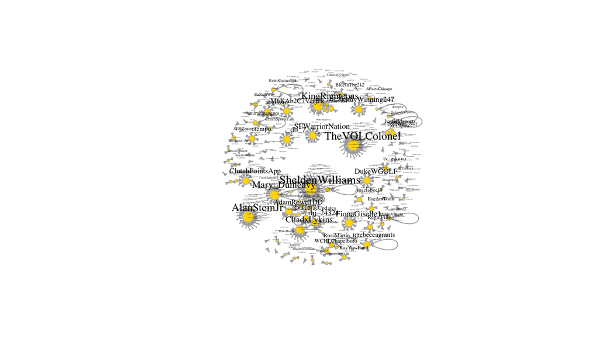

```r
plot(igra_duke_s,vertex.color="gold", vertex.size=log(degree(igra_duke_s))*3+1,
     vertex.frame.color="gray", vertex.label.color="black",
     vertex.label.cex=log(degree(igra_duke_s))*0.2+0.1, vertex.label.dist=2, edge.curved=0.5,edge.arrow.size=.2)
```

Friendship networks

directed: following

`get_friends()`: Get user IDs of accounts followed by target user(s).

```r
rt_dukembb <- search_tweets(
  "#dukebasketball", n = 1000
)
```

```
## Searching for tweets...
```

```
## Finished collecting tweets!
```

```r
names(rt_dukembb)
```

```
##  [1] "user_id"                 "status_id"
##  [3] "created_at"              "screen_name"
##  [5] "text"                    "source"
##  [7] "display_text_width"      "reply_to_status_id"
##  [9] "reply_to_user_id"        "reply_to_screen_name"
## [11] "is_quote"                "is_retweet"
## [13] "favorite_count"          "retweet_count"
## [15] "hashtags"                "symbols"
## [17] "urls_url"                "urls_t.co"
## [19] "urls_expanded_url"       "media_url"
## [21] "media_t.co"              "media_expanded_url"
## [23] "media_type"              "ext_media_url"
## [25] "ext_media_t.co"          "ext_media_expanded_url"
## [27] "ext_media_type"          "mentions_user_id"
## [29] "mentions_screen_name"    "lang"
```

[output cut: 29 more lines]

```r
users=rt_dukembb$user_id%>%unique()

##maximum ids: 100
abc=get_friends(users[1:5],n=100,retryonratelimit = TRUE)
```

```
## 1 friend networks collected!
```

```
## 2 friend networks collected!
```

```
## 3 friend networks collected!
```

```
## 4 friend networks collected!
```

```
## 5 friend networks collected!
```

```r
abc%>%filter(user_id%in%users)
```

```
## # A tibble: 6 x 2
##   user                user_id
##   <chr>               <chr>
## 1 220727776           854840291748188161
## 2 1089436063645327360 185796887
## 3 1089436063645327360 4915785719
## 4 1089436063645327360 892240725341032449
## 5 1089436063645327360 111688605
## 6 108631407           19346784
```

What if more than 100 ids?

```r
for (i in --){
  mat=get_friends(users[--])%>%filter(user_id%in%users)
  limit <- rate_limit("get_friends")
  if (--){
    Sys.sleep(--)
  }
}
```

## `rate_limit`

https://developer.twitter.com/en/docs/developer-utilities/rate-limit-status/api-reference/get-application-rate_limit_status

```r
rate_limit()%>%head()
```

```
## # A tibble: 6 x 7
##   query limit remaining reset reset_at            timestamp           app
##   <chr> <int>     <int> <tim> <dttm>              <dttm>              <chr>
## 1 list…    15        15 15.0… 2019-02-19 13:17:29 2019-02-19 13:02:26 Test…
## 2 list…    75        75 15.0… 2019-02-19 13:17:29 2019-02-19 13:02:26 Test…
## 3 list…    15        15 15.0… 2019-02-19 13:17:29 2019-02-19 13:02:26 Test…
## 4 list…   900       900 15.0… 2019-02-19 13:17:29 2019-02-19 13:02:26 Test…
## 5 list…    15        15 15.0… 2019-02-19 13:17:29 2019-02-19 13:02:26 Test…
## 6 list…    75        75 15.0… 2019-02-19 13:17:29 2019-02-19 13:02:26 Test…
```

```r
rate_limit("get_friends")
```

```
## # A tibble: 1 x 7
##   query limit remaining reset reset_at            timestamp           app
##   <chr> <int>     <int> <tim> <dttm>              <dttm>              <chr>
## 1 frie…    15        10 4.60… 2019-02-19 13:07:02 2019-02-19 13:02:26 Test…
```

```r
for (i in --){
  mat=get_friends(users[--])%>%filter(user_id%in%users)
  limit <- rate_limit("get_friends")
  if (limit$remaining==0){
    Sys.sleep(60)
  }
}
```